# Aside

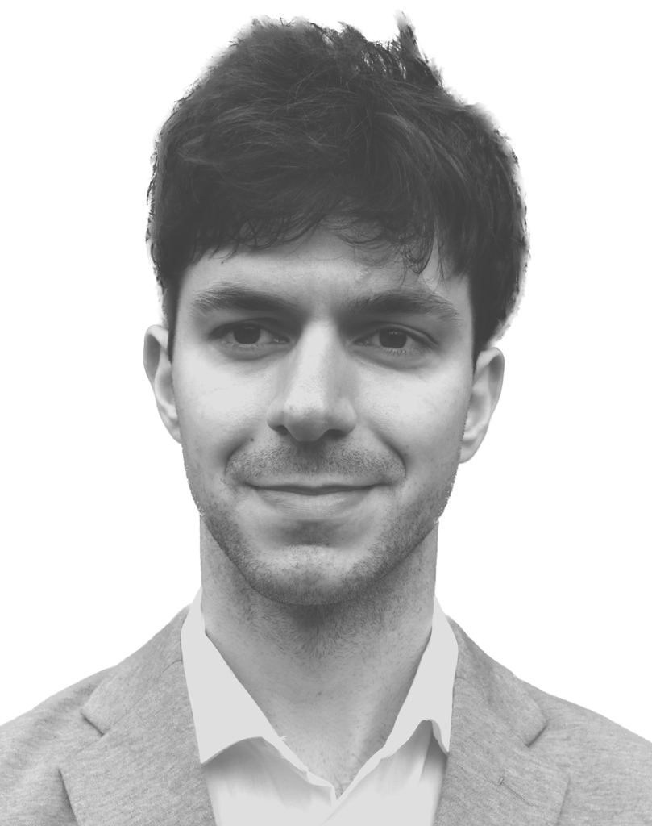

## Contact

- Ontario
- [Personal Website](https://bainmatt.github.io)
- [GitHub](https://github.com/bainmatt)
- [LinkedIn](https://www.linkedin.com/in/bainmatt/)

[Download as a PDF](https://bainmatt.github.io/cv/cv_matthewbain.pdf)

## Core tools

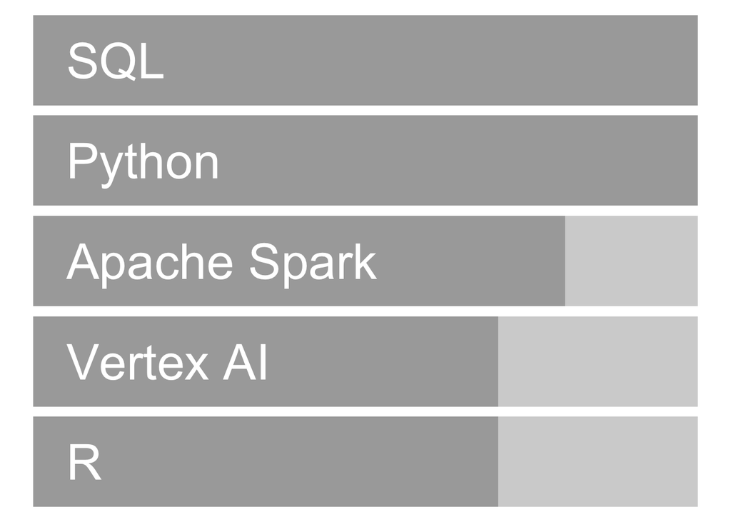

## Platforms

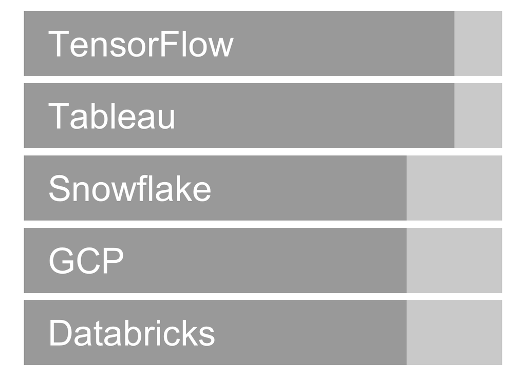

## Key competencies

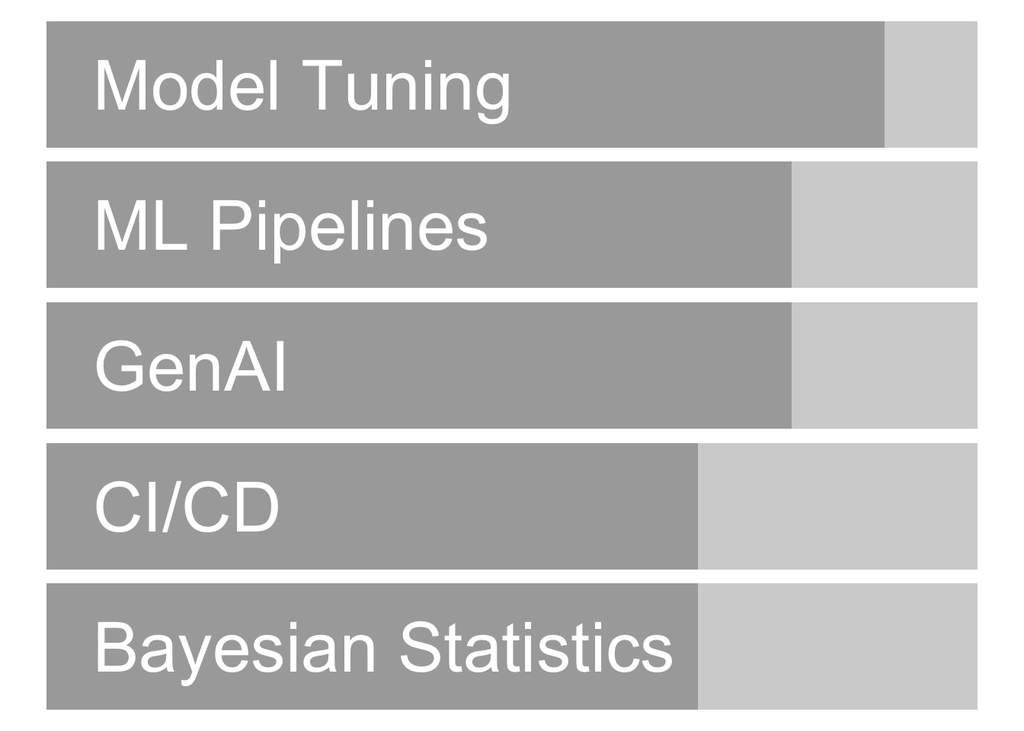

Last updated on 2025-12-04.

# Main

## Matthew Bain

### Data Engineer at Madiba Inc.

Data professional with 5+ years of experience building statistical solutions at scale. My work spans neuroscience, assistive tech, and housing, with a focus on statistically sound, interpretable machine learning. I help organizations understand their data and automate the hard stuff.

[figure not shown]

## Professional Experience

### Data Engineer

Madiba Inc.

Irvine, Califonia

Present - Sep 2025

- Build statistical tools and machine learning models to identify customer segmentation patterns, forecast demand, and predict churn within housing datasets (Python, Scikit-learn)
- Tune statistical and machine learning models and visualize their outputs using plotting libraries, interactive application frameworks, and reporting tools to convey key insights to executives (Snowflake, Streamlit)

### Open Source Developer

Independent

Toronto, ON

Aug 2025 - Jan 2024

- Developed a software package [[datopy](https://datopy.readthedocs.io/latest/)] simplifying data model design and ETL workflows (Python, Pandas)
- Built a data management package [[autocv](https://bainmatt.github.io/autocv/)] automating job application workflows (R, Excel)

### Data Analyst

VocaLinks Inc.

Toronto, ON

Oct 2023 - Jun 2023

- Created and communicated market breakdowns and technical tutorials (R Markdown, Python) on 4 AI-assisted assistive technology products, facilitating data-driven discussions among industry leaders
- Distilled key statistical insights in hearing research into visually compelling reports (ggplot (R), Seaborn), driving a 100% increase in sales of an assistive listening product
- Designed the data layer of an Azure speech recognition data center, enabling rapid delivery of meaningful analytics to 200+ customers via the cloud

### Research Analyst

University of Western Ontario

London, ON

Aug 2022 - Sep 2021

- Designed scalable online experiments (AWS, Amazon MTurk, JavaScript) to expedite data collection for 3 auditory neuroscience projects, yielding 2 publications and a robust cloud infrastructure
- Provided multivariate statistical modeling support for research on neural signatures of epilepsy, laying the groundwork for automated labeling of 10+ hours of multimedia stimuli (Python, GCP)

### Cognitive Neuroscientist

University of Western Ontario

London, ON

Aug 2021 - Jul 2018

- Designed and deployed 11 experiments assessing neural speech processing in 300+ research subjects
- Developed a time series analysis toolbox (R, MATLAB) to measure hearing impairment through brain imaging, enhancing diagnostic sensitivity by a factor of 2

### Graduate Teaching Assistant

University of Western Ontario

London, ON

Apr 2021 - Sep 2018

- Directed 4 weekly research methods and statistics labs for 100+ undergraduate neuroscience students, leading to a nomination recognizing excellence in teaching and mentorship

## Education

### BSc (Honours), Mathematics and Statistics

McMaster University

Hamilton, ON

Dec 2023 - Sep 2021

### MSc, Neuroscience [[Thesis](https://ir.lib.uwo.ca/etd/7475/)]

University of Western Ontario

London, ON

Aug 2020 - Sep 2018

### BSc (Honours), Neuroscience

McMaster University

Hamilton, ON

Apr 2018 - Sep 2014

## Certifications

### Databricks Certified Data Engineer Associate [[Certificate](https://credentials.databricks.com/d23633f5-0d08-407d-a9e5-d7b80f1bcce0#acc.yrKoInbw)]

Databricks

N/A

Mar 2027 - Mar 2025

### Tableau Certified Data Analyst [[Certificate](https://www.credly.com/badges/fed289e9-6a33-4a5d-842a-2067eae3936c)]

Tableau

N/A

Feb 2027 - Feb 2025

### Professional Machine Learning Engineer

Google Cloud Platform (GCP)

N/A

Expected Feb 2026

### Machine Learning Specialization [[Certificate](https://coursera.org/share/3bf1c195680d9d509c94741f1e70a1fe)]

Stanford University

N/A

Dec 2024

## Selected Projects

### datopy (Data Management Python Package) [[Documentation](https://datopy.readthedocs.io/latest/)]

N/A

N/A

Present - Jan 2024

- Implemented and maintain a package for handling unstructured data, providing a simple interface for data modeling, extraction, validation, and building ETL pipelines (Pandas, PyTest, Pydantic, GitHub Actions)

### mlvizz (Machine Learning Data Visualization Package)

N/A

N/A

Present - Apr 2024

- Build Python interfaces for efficient, intuitive model selection, tuning, inspection, and ML pipelines through modular, object-oriented designs with built-in data validation (Scikit-learn, TensorFlow, ArviZ, PyMC, SciPy)

### statvizz (Statistical Data Visualization Package)

N/A

N/A

Present - Apr 2024

- Build Python extensions unifying Pandas data summarization with Seaborn statistical plotting functionality for a unified, intuitive, fully transparent statistical plotting interface (Pandas, Seaborn, SciPy, Matplotlib)

### mathvizz (Mathematical Visualization Package)

N/A

N/A

Present - Jul 2024

- Build Python interfaces for exploring the geometry of machine learning math, including linear maps, derivatives, statistical distributions, and series approximations (SymPy, SciPy, Seaborn, Matplotlib)

### One-stop Superstore Dashboard [[Tableau](https://public.tableau.com/app/profile/mattbain/viz/One-stopsuperstoredash/dash)]

N/A

N/A

Feb 2025 - Feb 2025

- Designed an interactive dashboard displaying sales in a convenient, unified view, with key KPIs and sales logs visualized in both space and time (SQL, Excel)

### autocv (Automated CV-generation R Package) [[Documentation](https://bainmatt.github.io/autocv/)]

N/A

N/A

Jul 2024 - May 2024

- Built a data management package automating job application workflows using validated data stores and macro-integrated spreadsheets, resulting in an efficient, extensible workflow (dplyr (R), pkgdown, Excel)